# How to use dataplot

Ujang Fahmi $ Frey

2020-02-28

Visualisasi merupakan salah satu cara untuk mengomunikasikan hasil analisis. Selain itu, visualiasi juga merupakan salah satu teknik yang akan sangat bermanfaat dalam proses ekplorasi data. Package ini dibuat untuk digunakan untuk mencapai keduanya. Package ini sendiri merupakan adaptasi dari beberapa pacakage di R yang sudah ada sebelumnya seperti `bbplot` dari bbc, `cowplot`, `hbrthemes` dan lain-lain.

Package ini digunakan untuk membuat plot statis berdasarkan package `ggplot2` dengan beberapa modifikasi dilakukan pada beberapa bagian berikut:

- Judul (title) dan Sub Judul (Subtitle)
- Captioan atau footer
- Geom yang dimanfaatkan secara langsung untuk memetakan variabel yang ingin diplotkan

## Persiapan penggunaan

### Fonts

Fonts yang digunakan dalam template plot di package ini adalah keluarga Roboto. Untuk itu, jika dalam mesin anda belum menginstall font tersebut kami sarankan untuk menginstallnya terlebih dahulu. Untuk mempermudah, di dalam package ini kami juga membuat sebuah fungsi `import_fonts()` untuk mengambil fonts yang dibutuhkan yang telah kami sertakan dalam package. Untuk menggunakannya, kita bisa mengkopi paste dengan menjalankan skrip berikut:

```r
library(dataplot)

# type y on the console
dataplot::import_fonts()
```

Untuk mengimpor fonts yang ada di dalam package anda perlu mengeti `y` pada saat menjalankan skrip diatas.

### Logo

logo akan digunakan dalam fungsi untuk finishing. Secara default logo akan diambil dari package, yaitu logo kedata. Format yang digunakan adalah `.png`. Jika ingin membuat plot dengan logo milik sendiri maka anda bisa menggunakan fungsi `kedata_custom()`. Jika anda menggunakan fungsi tersebut, maka anda harus menyatakan folder dan file dalam fungsi.

### Footer

Footer digunakan untuk menempatkan caption di sebelah kiri plot dan logo di sebelah kanan. Secara default footer berwarna gelap, jika anda ingin mengubah warnanya bisa dilakukan dengan fungsi `kedata_custom()` dan mengisi parameter warna/color dengan kode hexagon dari warna.

## Membuat plot dengan Template

Package ini memiliki 4 fungsi utama untuk membuat sebuah plot, yaitu: (1) `kedata_theme()`; (2) `kedata_final1()`; (3). `kedata_final2()`; (4) `kedata_custom()`. Berikut adalah contoh penggunaannya.

1. `kedata_theme()`

Fungsi ini berguna untuk membuat tema bagian tengah plot agar menggunakan fonts, ukuran fonts, strip dan background yang sesuai. Semua dilakukan dibawah fungsi `theme()` dari `ggplot2`.

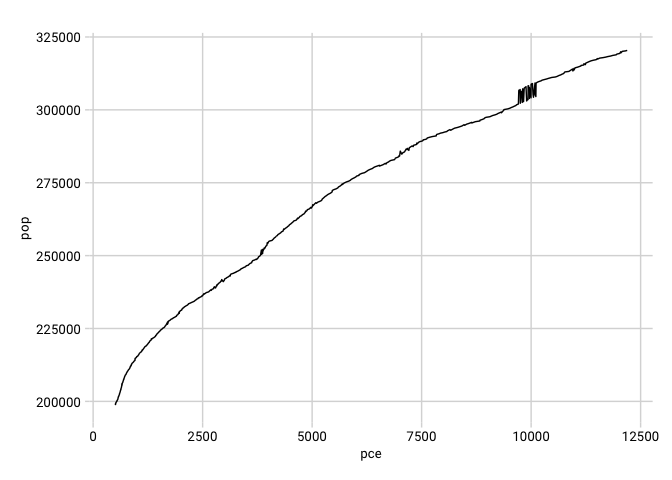

```r
library(dataplot)
library(ggplot2)

p1 = ggplot(data = economics, aes(x = pce, y = pop)) +
  geom_line() +
  kedata_theme()
p1
```

2. `kedata_final1()`

Finalisasi ini digunakan untuk menambhakan logo kedata pada bagain pojok kanan atas. Dilakukan dengan menggunakan arrangement image dar `grid`.

[figure not shown]

```r
library(dataplot)
library(ggplot2)

p1 = ggplot(data = economics, aes(x = pce, y = pop)) +
  geom_line() +
  kedata_theme()

p2 <- kedata_final1(plotname = p1,
                    title = "Lorem Ipsum is simply dummy text",
                    subtitle = "Contrary to popular belief, Lorem Ipsum is not simply random text")
p2
```

3. `kedata_final2()`

Fungsi finalisasi ini digunakan untuk menambahkan footer, logo, dan text pada bagian bawah plot. Selain itu, fungsi ini juga dilakukan untuk membuat judul dan subjudul rata kiri dengan text sumbu vertikal.

[figure not shown]

```r
library(dataplot)
library(ggplot2)

p1 = ggplot(data = economics, aes(x = pce, y = pop)) +
  geom_line() +
  kedata_theme()

p3 <- kedata_final2(plotname = p1,
              title = "Lorem Ipsum is simply dummy text",
              subtitle = "Contrary to popular belief, Lorem Ipsum is not simply random text",
              data_source = "Sumber Data")

p3
```

4. `kedata_custom()`

Fungsi ini digunakan untuk membuat finalisasi custom. Hal yang bisa dicustom saat ini pada bagian background footer dan logo yang digunakan juga pada bagian footer.

[figure not shown]

```r
library(dataplot)
library(ggplot2)

p1 = ggplot(data = economics, aes(x = pce, y = pop)) +
  geom_line(color = "#E0A526") +
  kedata_theme()

p4 <- kedata_custom(plotname = p1,
              footer_col = "#BB4628",
              logo = system.file("extdata/logo/", "contohlogo.png", package = "dataplot"),
              title = "Lorem Ipsum is simply dummy text",
              subtitle = "Contrary to popular belief, Lorem Ipsum is not simply random text",
              data_source = "www.sadasa.id")

p4
```

## Bonus Plot

### Hydrograph

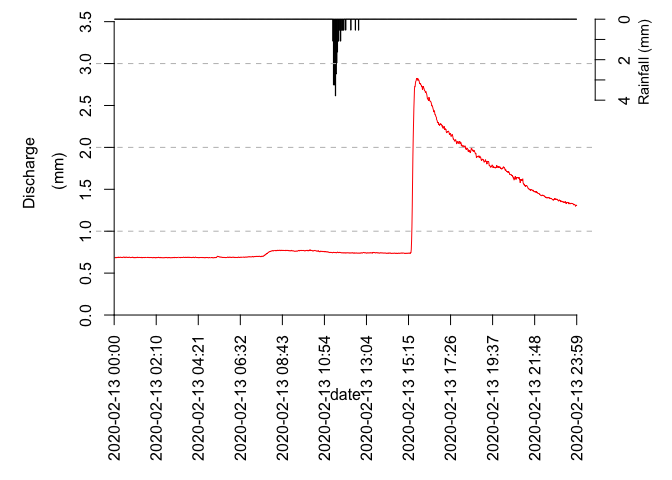

```r
rainfall <- dataplot::rainfall

plot_hydrograph(timeSeries = rainfall$`Date Time`,
           streamflow = rainfall$Discharge,
           precip = rainfall$`Rainfall depth (mm)`,
           S1.col = "red",
           left_label = "Discharge", S.units = "mm",
           right_label = "Rainfall", P.units = "mm")
```

Plot tersebut dibuat dari data frame yang berisi 3 variabel. Di mana varaibel pertama harus merupakan data dengan jenis date time.

## Jenis Plot

Jenis plot yang dibuat di sini diadaptasi dari postingan `Prabhakaran`[^1], dan postingan teman-teman R Community di Twitter[^2]. Untuk mengetahui penggunaan masing-masing fungsi membuat plot, bisa melihat dokumentasi berikut:

1. Correlation Plot, lihat `vignette(correlation_plot)`
2. Deviation Plot, lihat `vignette(deviation)`
3. Ranking Plot, lihat `vignette(ranking)`
4. Distribution Plot, lihat `vignette(distribution)`
5. Composition Plot, lihat `vignette(composition_plot)`
6. Change Plot, lihat `vignette(change_plot)`
7. Groups Plot, lihat `vignette(group_plot)`
8. Spatial Plot, lihat `vignette(sp_plot)`

Cara cepat untuk mengakses dokuemnatasi di atas adalah dengan menggunakan fungsi `vignette(nama_dokuemnatasi)` di bagian console Secara umum dokumentasi-dokumentasi diatas akan menjelaskan penggunaan dan konsep yang digunakan untuk membuat sebuah plot.

[^1]: [Top 50 ggplot2 Visualizations](http://r-statistics.co/Complete-Ggplot2-Tutorial-Part2-Customizing-Theme-With-R-Code.htmlex)
[^2]: [TidyTuesday](https://twitter.com/search?q=%23TidyTuseday&src=typed_query)